# SI 618 WN 2018 - Homework 5: Using the Spark SQL to analyze Yelp Business Data

## Objectives

1. To gain familiarity with Spark SQL;
2. To master filtering, aggregating, and sorting a Spark DataFrame;
3. To learn joining multiple Spark DataFrames;
4. To review visualizing Pandas DataFrame using Seaborn.

## Please fill in...

### * Your name: Raphael Ku

### * People you worked with: I worked by myself

## Submission Instructions:

Please turn in this Jupyter notebook file (in both .ipynb and .html formats) via Canvas.

## Overview

This project is designed to give you a basic familiarity with the Apache Spark SQL module.

## Data

We are going to use Yelp academic dataset. We will conduct a city-level analysis throughout the assignment. The descriptions of the data can be found on here: https://www.yelp.com/dataset/documentation/json

```python
from pyspark.sql import SparkSession
```

### Step 1a: Initialize a SparkSession

```python
spark = SparkSession.builder.appName('HW5').getOrCreate()
```

### Step 1b: Load the JSON file into Spark

```python
df = spark.read.json('yelp_academic_dataset_business.json')
```

### Step 1c: Print the schema and familiarize yourself with the structure of the dataset

```python
df.printSchema() # change this line of code
```

```
root
 |-- attributes: struct (nullable = true)
 |    |-- Accepts Credit Cards: boolean (nullable = true)
 |    |-- Accepts Insurance: boolean (nullable = true)
 |    |-- Ages Allowed: string (nullable = true)
 |    |-- Alcohol: string (nullable = true)
 |    |-- Ambience: struct (nullable = true)
 |    |    |-- casual: boolean (nullable = true)
 |    |    |-- classy: boolean (nullable = true)
 |    |    |-- divey: boolean (nullable = true)
 |    |    |-- hipster: boolean (nullable = true)
 |    |    |-- intimate: boolean (nullable = true)
 |    |    |-- romantic: boolean (nullable = true)
 |    |    |-- touristy: boolean (nullable = true)
 |    |    |-- trendy: boolean (nullable = true)
 |    |    |-- upscale: boolean (nullable = true)
 |    |-- Attire: string (nullable = true)
 |    |-- BYOB: boolean (nullable = true)
 |    |-- BYOB/Corkage: string (nullable = true)
 |    |-- By Appointment Only: boolean (nullable = true)
 |    |-- Caters: boolean (nullable = true)
 |    |-- Coat Check: boolean (nullable = true)
 |    |-- Corkage: boolean (nullable = true)
 |    |-- Delivery: boolean (nullable = true)
 |    |-- Dietary Restrictions: struct (nullable = true)
 |    |    |-- dairy-free: boolean (nullable = true)
 |    |    |-- gluten-free: boolean (nullable = true)
 |    |    |-- halal: boolean (nullable = true)
 |    |    |-- kosher: boolean (nullable = true)
 |    |    |-- soy-free: boolean (nullable = true)
 |    |    |-- vegan: boolean (nullable = true)
 |    |    |-- vegetarian: boolean (nullable = true)
 |    |-- Dogs Allowed: boolean (nullable = true)
 |    |-- Drive-Thru: boolean (nullable = true)
 |    |-- Good For: struct (nullable = true)
 |    |    |-- breakfast: boolean (nullable = true)
 |    |    |-- brunch: boolean (nullable = true)
 |    |    |-- dessert: boolean (nullable = true)
 |    |    |-- dinner: boolean (nullable = true)
 |    |    |-- latenight: boolean (nullable = true)
```

[output cut: 61 more lines]

```
 |    |    |-- close: string (nullable = true)
 |    |    |-- open: string (nullable = true)
 |    |-- Wednesday: struct (nullable = true)
 |    |    |-- close: string (nullable = true)
 |    |    |-- open: string (nullable = true)
 |-- latitude: double (nullable = true)
 |-- longitude: double (nullable = true)
 |-- name: string (nullable = true)
 |-- neighborhoods: array (nullable = true)
 |    |-- element: string (containsNull = true)
 |-- open: boolean (nullable = true)
 |-- review_count: long (nullable = true)
 |-- stars: double (nullable = true)
 |-- state: string (nullable = true)
 |-- type: string (nullable = true)
```

## The analyses below are focused on the businesses in United State.

```python
us_states_list = ["SC","AZ","MN","NV","WI","CA","NC","IL","AL","NM","PA","TX","FL","AK"]
```

### Step 2: Filter "df" to include only businesses in the United States.

```python
US = df.filter(df['state'].isin(us_states_list))
# change this line of code
```

### Step 3: Show the U.S. cities, and their number of businesses in descending order.

```python
US_count = US.groupby('city').count().sort('count', ascending=False)
# change this line of code
US_count.show()
```

```
+---------------+-----+
|           city|count|
+---------------+-----+
|      Las Vegas|19327|
|        Phoenix|11852|
|      Charlotte| 5695|
|     Scottsdale| 5638|
|           Mesa| 3638|
|     Pittsburgh| 3628|
|      Henderson| 3145|
|          Tempe| 3043|
|       Chandler| 2702|
|        Madison| 2278|
|       Glendale| 2048|
|        Gilbert| 1941|
|         Peoria| 1081|
|North Las Vegas|  952|
|       Surprise|  681|
|       Goodyear|  507|
|      Champaign|  505|
|       Avondale|  427|
|       Matthews|  399|
|    Queen Creek|  383|
+---------------+-----+
only showing top 20 rows
```

### Step 4: Show the frequency distribution of stars in the U.S., ordered by stars from 1.0 to 5.0.

```python
US_stars_distribution = US.groupby('stars').count().sort('stars') # change this line of code
US_stars_distribution.show()
```

```
+-----+-----+
|stars|count|
+-----+-----+
|  1.0| 1041|
|  1.5| 1770|
|  2.0| 3494|
|  2.5| 6768|
|  3.0| 9709|
|  3.5|14146|
|  4.0|14480|
|  4.5|11467|
|  5.0|12349|
+-----+-----+
```

### Step 5a: Find the list of U.S. cities that have at least(>=) 50 businesses.

```python
cities = US_count.filter(US_count['count'] >= 50)
cities.show(1200)
# change this line of code; use multiple lines of code if needed
```

```
+---------------+-----+
|           city|count|
+---------------+-----+
|      Las Vegas|19327|
|        Phoenix|11852|
|      Charlotte| 5695|
|     Scottsdale| 5638|
|           Mesa| 3638|
|     Pittsburgh| 3628|
|      Henderson| 3145|
|          Tempe| 3043|
|       Chandler| 2702|
|        Madison| 2278|
|       Glendale| 2048|
|        Gilbert| 1941|
|         Peoria| 1081|
|North Las Vegas|  952|
|       Surprise|  681|
|       Goodyear|  507|
|      Champaign|  505|
|       Avondale|  427|
|       Matthews|  399|
|    Queen Creek|  383|
|      Fort Mill|  287|
|         Urbana|  286|
|     Cave Creek|  266|
|      Middleton|  222|
|      Pineville|  210|
| Fountain Hills|  204|
|    Casa Grande|  201|
|Apache Junction|  186|
|        Concord|  185|
|       Maricopa|  165|
|        Buckeye|  163|
|      Fitchburg|  136|
|         Anthem|  135|
|    Sun Prairie|  129|
|       Sun City|  126|
|Litchfield Park|  120|
| San Tan Valley|  100|
|      Homestead|   98|
|         Laveen|   96|
|       Tolleson|   90|
|Paradise Valley|   90|
|         Monona|   85|
|        Belmont|   83|
|     Wickenburg|   78|
|         Verona|   67|
|   Indian Trail|   67|
|      El Mirage|   63|
|       Carnegie|   62|
|       Carefree|   54|
|      Mint Hill|   50|
+---------------+-----+
```

### Step 5b: Filter "US" using the list of cities from 6a, to restrict our attention to cities with at least 50 businesses reviewed.

```python
US = US.join(cities, on='city', how='inner').drop('count')
US.show()
# change this line of code
```

```
+----------+--------------------+--------------------+--------------------+--------------------+--------------------+----------------+-----------------+--------------------+-------------+-----+------------+-----+-----+--------+
|      city|          attributes|         business_id|          categories|        full_address|               hours|        latitude|        longitude|                name|neighborhoods| open|review_count|stars|state|    type|
+----------+--------------------+--------------------+--------------------+--------------------+--------------------+----------------+-----------------+--------------------+-------------+-----+------------+-----+-----+--------+
|  Carnegie|[true,null,null,f...|KayYbHCt-RkbGcPdG...|[Bars, American (...|141 Hawthorne St
...|[[02:00,11:00],[0...|      40.4154859|      -80.0675491|Alexion's Bar & G...|  [Greentree]| true|          23|  4.0|   PA|business|
|  Carnegie|[true,null,null,n...|b12U9TFESStdy7CsT...|[Auto Repair, Aut...|718A Hope Hollow ...|[[18:00,07:30],[1...|       40.394588|      -80.0844539|Flynn's Tire & Au...|           []| true|           9|  2.5|   PA|business|
|  Carnegie|[null,null,null,n...|Sktj1eHQFuVa-M4bg...|[Active Life, Min...|920 Forsythe Rd
C...|[null,null,null,n...|      40.4054039|      -80.0762665|Forsythe Miniatur...|   [Carnegie]|false|           4|  4.0|   PA|business|
|  Carnegie|[null,null,null,n...|3ZVKmuK2l7uXPE6lX...|[Roofing, Home Se...|8 Logan St
Carneg...|[null,null,null,n...|      40.4062805|      -80.0903905|Quaker State Cons...|   [Carnegie]| true|           3|  2.5|   PA|business|
|Pittsburgh|[null,null,null,n...|QoDa50dc7g62xciFy...|[Veterinarians, P...|2080 Greentree Rd...|[null,null,null,n...|      40.3922071|      -80.0691338|Greentree Animal ...|           []| true|           7|  4.0|   PA|business|
|  Carnegie|[null,null,null,n...|1_lU0-eSWJCRvNGk7...|[Libraries, Publi...|300 Beechwood Ave...|[null,null,null,n...|      40.4068423|      -80.0858661|Carnegie Free Lib...|   [Carnegie]| true|           4|  4.5|   PA|business|
|  Carnegie|[null,null,null,n...|_qopVQ6_Mz6W7-Pmb...|[Automotive, Auto...|1011 Washington A...|[null,null,null,n...|      40.3983526|      -80.0824517|  Advance Auto Parts|           []| true|           3|  3.5|   PA|business|
|  Carnegie|[true,null,null,n...|wJr6kSA5dchdgOdwH...|[Burgers, Breakfa...|2100 Washington P...|[[02:00,08:00],[0...|      40.3875124|      -80.0932152|Kings Family Rest...|           []| true|          10|  3.5|   PA|business|
|  Carnegie|[true,null,null,n...|yXuao0pFz1AxB21vJ...|     [Food, Grocery]|2100 Washington P...|[[00:00,00:00],[0...|      40.3875124|      -80.0932152|        Shop N' Save|           []| true|           5|  4.0|   PA|business|
|  Carnegie|[null,null,null,n...|LLJMI-_fSp6OYQuY4...|[Automotive, Gas ...|341 E Main St
Car...|[null,null,null,n...|      40.4099977|      -80.0833664|Knorr's Sunoco Se...|   [Carnegie]| true|           3|  3.5|   PA|business|
|  Carnegie|[true,null,null,n...|F04xyOUA2xnUoCiWp...|[Local Services, ...|Bower Hill Rd & V...|[null,null,null,n...|40.3688246816964|-80.0843536574327|Rossi Tailoring &...|           []| true|           3|  3.0|   PA|business|
|  Carnegie|[null,null,null,n...|Cdcus0NADzyY3XiJM...|[Automotive, Gas ...|1927 E Railroad S...|[null,null,null,n...|       40.388284|       -80.089241|      Heidelberg B P|           []|false|           4|  3.0|   PA|business|
|  Carnegie|[true,null,null,f...|fNGIbpazjTRdXgwRY...|[Bars, American (...|1201 Washington A...|[[23:00,11:00],[2...|      40.3964688|      -80.0849416|      Rocky's Lounge|           []| true|          10|  4.0|   PA|business|
|  Carnegie|[false,null,null,...|b9WZJp5L1RZr4F1nx...|[Breakfast & Brun...|1073 Washington A...|[[14:30,06:00],[1...|      40.3980013|      -80.0834577|           Gab & Eat|           []| true|          69|  4.5|   PA|business|
|  Carnegie|[true,null,null,n...|zaXDakTd3RXyOa7sM...|[Cafes, Restaurants]|202 3rd Ave
Carne...|[[14:00,07:00],[1...|       40.404638|       -80.089985|Barb's Country Ju...|   [Carnegie]| true|           9|  4.0|   PA|business|
|  Carnegie|[true,null,null,n...|zgy27FSnvwdINfk5c...|[Hotels & Travel,...|520 North Bell Av...|[[00:00,00:00],[0...|       40.417419|       -80.088557|Extended Stay Ame...|   [Carnegie]| true|          11|  3.5|   PA|business|
|  Carnegie|[true,null,null,f...|WETE_LykpcnrC1sFc...|[Pubs, Irish, Nig...|215 E Main St
Car...|[null,null,null,n...|        40.40867|       -80.085279|  Paddy's Pour House|   [Carnegie]|false|           8|  3.5|   PA|business|
|  Carnegie|[null,null,null,n...|6o3RK6rTcN3nw-j-r...|[Pizza, Restaurants]|231 E Main St
Car...|[[00:00,11:00],[2...|       40.408832|      -80.0849338|Porto Fino Pizzar...|   [Carnegie]| true|           4|  2.5|   PA|business|
|  Carnegie|[false,null,null,...|woOVJ0Z2f6XNCDntH...|[Local Services, ...|117 E Mall Plz
Ca...|[[19:00,08:30],[1...|      40.4068712|      -80.0876046|    Alteration World|   [Carnegie]| true|          10|  4.5|   PA|business|
|  Carnegie|[true,null,null,n...|rv7CY8G_XibTx82Yh...|       [Restaurants]|Raceway Plz
Carne...|[null,null,null,n...|      40.3868915|      -80.0937037|  Long John Silver's|           []| true|           6|  3.0|   PA|business|
+----------+--------------------+--------------------+--------------------+--------------------+--------------------+----------------+-----------------+--------------------+-------------+-----+------------+-----+-----+--------+
only showing top 20 rows
```

### Step 6a: Compute the average stars for each city.

The Spark DataFrame should look similar to this:

| city | avg(stars) |
| --- | --- |
| San Diego | 3.5 |
| Pittsburgh | 3.5 |
| ... | ... |

```python
ratings = US.groupby('city').avg('stars')
ratings.show()
# change this line of code
```

```
+---------------+------------------+
|           city|        avg(stars)|
+---------------+------------------+
|          Tempe|3.7016102530397634|
|North Las Vegas| 3.463235294117647|
|        Phoenix| 3.685242996962538|
|      Fitchburg|3.5588235294117645|
|     Scottsdale|3.9065271372827244|
|Apache Junction| 3.596774193548387|
|       Chandler|3.7189119170984455|
|       Surprise|3.6754772393538913|
|Paradise Valley| 3.727777777777778|
|       Tolleson| 3.283333333333333|
|      Fort Mill|3.5714285714285716|
|Litchfield Park| 3.816666666666667|
|         Verona|3.8582089552238807|
|       Avondale|3.5327868852459017|
|        Buckeye|3.5276073619631902|
|     Wickenburg|3.7948717948717947|
| Fountain Hills| 3.857843137254902|
|    Sun Prairie| 3.554263565891473|
|        Madison| 3.675373134328358|
|    Casa Grande|3.5199004975124377|
+---------------+------------------+
only showing top 20 rows
```

### Step 6b: What are the top 5 cities with the highest average stars?

```python
ratings.sort('avg(stars)', ascending=False).show(5)
# change this line of code
```

```
+---------------+------------------+
|           city|        avg(stars)|
+---------------+------------------+
|     Scottsdale|3.9065271372827244|
|     Cave Creek| 3.892857142857143|
|         Verona|3.8582089552238807|
| Fountain Hills| 3.857843137254902|
|Litchfield Park| 3.816666666666667|
+---------------+------------------+
only showing top 5 rows
```

### Step 7a: Define a city's "weekend friendliness" as the percentage of businesses open on Saturday and Sunday. Create a Spark DataFrame "weekend_friendliness" that gives a "weekend friendliness" for each city.

#### Hint: use .isNotNull() in .filter()

The Spark DataFrame should look similar to this:

| city | weekend friendliness |
| --- | --- |
| San Diego | 0.5 |
| Pittsburgh | 0.5 |
| ... | ... |

```python
from pyspark.sql import functions as F
from pyspark.sql.functions import array_contains,col
#         # open on Saturday/Sunday | # total count | proportion
# city1
# city2
# change this line of code
null = []
weekend_friendliness = US.select('city', 'Hours', 'business_id', F.when((US['Hours']['Sunday'].isNotNull()) &\
                                                         (US['Hours']['Saturday'].isNotNull()), 1).otherwise(0).alias('weekend'))

weekend_friendliness = weekend_friendliness.filter(((US['Hours']['Saturday'].isNull())&\
                                             (US['Hours']['Sunday'].isNull())&\
                                             (US['Hours']['Monday'].isNull())&\
                                             (US['Hours']['Tuesday'].isNull())&\
                                             (US['Hours']['Wednesday'].isNull())&\
                                             (US['Hours']['Thursday'].isNull())&\
                                             (US['Hours']['Friday'].isNull())) == False)
weekend_friendliness = weekend_friendliness.groupby('city')\
.agg((F.sum('weekend')/F.count('weekend')).alias('weekend_friendliness')).select('city', 'weekend_friendliness')
weekend_friendliness.show()
```

```
+---------------+--------------------+
|           city|weekend_friendliness|
+---------------+--------------------+
|          Tempe|  0.5870463941203491|
|North Las Vegas|  0.6618357487922706|
|        Phoenix|  0.5677966101694916|
|      Fitchburg|   0.660377358490566|
|     Scottsdale|  0.5644964642770056|
|Apache Junction|  0.5963302752293578|
|       Chandler|  0.5952631578947368|
|       Surprise|  0.5892116182572614|
|Paradise Valley|               0.625|
|       Tolleson|  0.6727272727272727|
|      Fort Mill|  0.5798816568047337|
|Litchfield Park|  0.6067415730337079|
|         Verona|  0.5319148936170213|
|       Avondale|  0.6745762711864407|
|        Buckeye|  0.6888888888888889|
|     Wickenburg|   0.717948717948718|
| Fountain Hills|  0.5555555555555556|
|    Sun Prairie|  0.7528089887640449|
|        Madison|  0.6798396334478809|
|    Casa Grande|             0.59375|
+---------------+--------------------+
only showing top 20 rows
```

### Step 7b: What are the top 5 weekend friendly cities?

```python
weekend_friendliness.orderBy('weekend_friendliness', ascending=False).show(5)
```

```
+-----------+--------------------+
|       city|weekend_friendliness|
+-----------+--------------------+
|    Concord|  0.8650793650793651|
|     Monona|  0.8103448275862069|
|     Laveen|  0.7868852459016393|
|  Homestead|  0.7619047619047619|
|Sun Prairie|  0.7528089887640449|
+-----------+--------------------+
only showing top 5 rows
```

### Step 8a: Define a city's "nightlife hotness" as the percentage of businesses whose categories contains “Nightlife”. Create a Spark DataFrame "nightlife_hotness" that gives a "nightlife_hotness" for each city.

#### Hint1: use array_contains() to check if an element exists in a JSON array.

#### Hint2: use F.when() to make an binary variable to indicate if a business's categories contains "Nightlife".

The Spark DataFrame should look similar to this:

| city | nightlife_hotness |
| --- | --- |
| San Diego | 0.5 |
| Pittsburgh | 0.5 |
| ... | ... |

```python
from pyspark.sql import functions as F
from pyspark.sql.functions import array_contains,col


nightlife_hotness = \
US.select(US['city'], F.when(array_contains(US['categories'], 'Nightlife'), 1).otherwise(0).alias('nightyes'))\
.groupby('city').agg((F.sum('nightyes')/F.count('nightyes')).alias('nightlife_hotness'))
nightlife_hotness.show(5)
# change this line of code
```

```
+---------------+--------------------+
|           city|   nightlife_hotness|
+---------------+--------------------+
|          Tempe|0.056194544857048966|
|North Las Vegas| 0.03466386554621849|
|        Phoenix| 0.04210259871751603|
|      Fitchburg| 0.08823529411764706|
|     Scottsdale|0.060837176303653775|
+---------------+--------------------+
only showing top 5 rows
```

### Step 8b: What are the top 5 cities best for nightlife?

```python
nightlife_hotness.sort('nightlife_hotness', ascending=False).show(5) # change this line of code
```

```
+----------+-------------------+
|      city|  nightlife_hotness|
+----------+-------------------+
| Homestead| 0.1326530612244898|
|  Carefree|0.12962962962962962|
|    Verona|0.11940298507462686|
|  Carnegie|0.11290322580645161|
|Pittsburgh|0.10832414553472988|
+----------+-------------------+
only showing top 5 rows
```

### Step 9: Join the 3 DataFrames "ratings", "weekend_friendliness", and "nightlife_hotness". Convert the joined table into Pandas DataFrame.

| city | avg(stars) | weekend_friendliness | nightlife_hotness |
| --- | --- | --- | --- |
| San Diego | 0.5 | 0.5 | 3.5 |
| Pittsburgh | 0.5 | 0.5 | 3.5 |
| ... | ... | ... | ... |

```python
combine = ratings.join(weekend_friendliness, on='city', how='outer').join(nightlife_hotness, on='city', how='outer')
joined = combine.toPandas()
# change this line of code
joined.head(500)
```

|  | city | avg(stars) | weekend_friendliness | nightlife_hotness |
| --- | --- | --- | --- | --- |
| 0 | Tempe | 3.701610 | 0.587046 | 0.056195 |
| 1 | North Las Vegas | 3.463235 | 0.661836 | 0.034664 |
| 2 | Phoenix | 3.685243 | 0.567797 | 0.042103 |
| 3 | Fitchburg | 3.558824 | 0.660377 | 0.088235 |
| 4 | Scottsdale | 3.906527 | 0.564496 | 0.060837 |
| 5 | Apache Junction | 3.596774 | 0.596330 | 0.048387 |
| 6 | Chandler | 3.718912 | 0.595263 | 0.034419 |
| 7 | Surprise | 3.675477 | 0.589212 | 0.035242 |
| 8 | Paradise Valley | 3.727778 | 0.625000 | 0.077778 |
| 9 | Tolleson | 3.283333 | 0.672727 | 0.022222 |
| 10 | Fort Mill | 3.571429 | 0.579882 | 0.048780 |
| 11 | Litchfield Park | 3.816667 | 0.606742 | 0.050000 |
| 12 | Avondale | 3.532787 | 0.674576 | 0.025761 |
| 13 | Verona | 3.858209 | 0.531915 | 0.119403 |
| 14 | Buckeye | 3.527607 | 0.688889 | 0.042945 |
| 15 | Wickenburg | 3.794872 | 0.717949 | 0.064103 |
| 16 | Fountain Hills | 3.857843 | 0.555556 | 0.049020 |
| 17 | Sun Prairie | 3.554264 | 0.752809 | 0.077519 |
| 18 | Madison | 3.675373 | 0.679840 | 0.100088 |
| 19 | Casa Grande | 3.519900 | 0.593750 | 0.059701 |
| 20 | Matthews | 3.619048 | 0.646840 | 0.037594 |
| 21 | Pittsburgh | 3.723539 | 0.641755 | 0.108324 |
| 22 | Gilbert | 3.786708 | 0.523022 | 0.024214 |
| 23 | Glendale | 3.604980 | 0.621091 | 0.046387 |
| 24 | San Tan Valley | 3.695000 | 0.707317 | 0.020000 |
| 25 | Maricopa | 3.475758 | 0.621359 | 0.048485 |
| 26 | Las Vegas | 3.695064 | 0.651377 | 0.065142 |
| 27 | El Mirage | 3.571429 | 0.571429 | 0.015873 |
| 28 | Queen Creek | 3.715405 | 0.561798 | 0.039164 |
| 29 | Indian Trail | 3.641791 | 0.600000 | 0.000000 |
| 30 | Sun City | 3.496032 | 0.434211 | 0.007937 |
| 31 | Belmont | 3.759036 | 0.557692 | 0.036145 |
| 32 | Cave Creek | 3.892857 | 0.604520 | 0.052632 |
| 33 | Monona | 3.570588 | 0.810345 | 0.094118 |
| 34 | Henderson | 3.735930 | 0.597896 | 0.030843 |
| 35 | Pineville | 3.542857 | 0.654135 | 0.019048 |
| 36 | Peoria | 3.681314 | 0.598710 | 0.043478 |
| 37 | Goodyear | 3.538462 | 0.682857 | 0.031558 |
| 38 | Laveen | 3.182292 | 0.786885 | 0.031250 |
| 39 | Urbana | 3.559441 | 0.620879 | 0.045455 |
| 40 | Champaign | 3.545545 | 0.707463 | 0.106931 |
| 41 | Mint Hill | 3.520000 | 0.551724 | 0.020000 |
| 42 | Carnegie | 3.564516 | 0.617647 | 0.112903 |
| 43 | Mesa | 3.616685 | 0.526316 | 0.032435 |
| 44 | Concord | 3.381081 | 0.865079 | 0.048649 |
| 45 | Carefree | 3.787037 | 0.571429 | 0.129630 |
| 46 | Charlotte | 3.585689 | 0.640052 | 0.072695 |
| 47 | Anthem | 3.696296 | 0.548780 | 0.037037 |
| 48 | Middleton | 3.605856 | 0.730061 | 0.076577 |
| 49 | Homestead | 3.489796 | 0.761905 | 0.132653 |

### Step 10a: Create a pair-wise correlation matrix of "cities" using Pandas.

```python
joined.corr() # change this line of code
```

|  | avg(stars) | weekend_friendliness | nightlife_hotness |
| --- | --- | --- | --- |
| avg(stars) | 1.000000 | -0.479640 | 0.183445 |
| weekend_friendliness | -0.479640 | 1.000000 | 0.277682 |
| nightlife_hotness | 0.183445 | 0.277682 | 1.000000 |

### Step 10b: Create a pairplot of the three variables in "cities".

```python
import seaborn as sns
%matplotlib inline
```

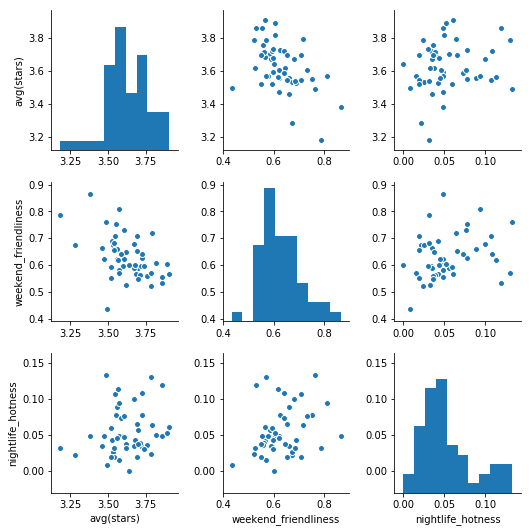

```python
sns.pairplot(joined)
```

### Step 10c: What is your interpretation of the correlations?

My interpretation would be that, based on the weak positive correlation coefficient of nightlife_hotness to the other 2 factors, the nightlife scene of a city may be independent from weekend friendliness or reviews.

For the moderate negative correlation for weekend_friendliness and avg(stars), this may be caused by a difference in clientele of establishments in the weekend vs. weekdays, as well as potentially just number of reviews. It also may be that the weekend_friendliness measurement of a city does not reflect the quality of establishments, as worse restaurants may choose to stay open on the weekend to gain more sales.

It may be worth looking into number of reviews received by establishments, in terms of relation to star rating, and days open. If there is a strong correlation on the establishment level, it may indicate that the moderate correlation on average stars and weekend_friendliness in the city level may have a confounding variable.

### Above and Beyond

My work can be considered for above and beyond credit for the following reasons:

- 1st question integrates using pyspark in a python function for use in the select method for Pyspark Dataframes, as well as trying to rename columns to remove the sum(x) format used to fit jupyter notebook view.
- 2nd question provides a geographic visualization of noise in Las Vegas, using Folium, in order to take advantage of data having latitude and longitude information

##### Additional Question 1

Schema indicates ambiance, can it be separated to see if there is any curious trends on which tags are common? Does it relate to noise level?

```python
def newamb(amb):
    return F.when(US['attributes.Ambience.{}'.format(amb)] == True, 1).otherwise(0).alias(amb)

noiselevel = F.when(US['attributes']['Noise Level'] == 'quiet', 1)\
            .when(US['attributes']['Noise Level'] == 'average', 2)\
            .when(US['attributes']['Noise Level'] == 'loud', 3)\
            .when(US['attributes']['Noise Level'] == 'very_loud', 4).otherwise(0).alias('noise')

new = US.select('city', 'name', newamb('casual'), newamb('classy'), newamb('divey'),\
                newamb('hipster'), newamb('intimate'), newamb('romantic'), newamb('touristy'),\
                newamb('trendy'), newamb('upscale'), noiselevel)
new.show()
```

```
+----------+--------------------+------+------+-----+-------+--------+--------+--------+------+-------+-----+
|      city|                name|casual|classy|divey|hipster|intimate|romantic|touristy|trendy|upscale|noise|
+----------+--------------------+------+------+-----+-------+--------+--------+--------+------+-------+-----+
|  Carnegie|Alexion's Bar & G...|     1|     0|    0|      0|       0|       0|       0|     0|      0|    3|
|  Carnegie|Flynn's Tire & Au...|     0|     0|    0|      0|       0|       0|       0|     0|      0|    0|
|  Carnegie|Forsythe Miniatur...|     0|     0|    0|      0|       0|       0|       0|     0|      0|    0|
|  Carnegie|Quaker State Cons...|     0|     0|    0|      0|       0|       0|       0|     0|      0|    0|
|Pittsburgh|Greentree Animal ...|     0|     0|    0|      0|       0|       0|       0|     0|      0|    0|
|  Carnegie|Carnegie Free Lib...|     0|     0|    0|      0|       0|       0|       0|     0|      0|    0|
|  Carnegie|  Advance Auto Parts|     0|     0|    0|      0|       0|       0|       0|     0|      0|    0|
|  Carnegie|Kings Family Rest...|     0|     0|    0|      0|       0|       0|       0|     0|      0|    0|
|  Carnegie|        Shop N' Save|     0|     0|    0|      0|       0|       0|       0|     0|      0|    0|
|  Carnegie|Knorr's Sunoco Se...|     0|     0|    0|      0|       0|       0|       0|     0|      0|    0|
|  Carnegie|Rossi Tailoring &...|     0|     0|    0|      0|       0|       0|       0|     0|      0|    0|
|  Carnegie|      Heidelberg B P|     0|     0|    0|      0|       0|       0|       0|     0|      0|    0|
|  Carnegie|      Rocky's Lounge|     0|     0|    1|      0|       0|       0|       0|     0|      0|    2|
|  Carnegie|           Gab & Eat|     0|     0|    1|      0|       0|       0|       0|     0|      0|    2|
|  Carnegie|Barb's Country Ju...|     0|     0|    0|      0|       0|       0|       0|     0|      0|    2|
|  Carnegie|Extended Stay Ame...|     0|     0|    0|      0|       0|       0|       0|     0|      0|    0|
|  Carnegie|  Paddy's Pour House|     0|     0|    0|      0|       0|       0|       0|     0|      0|    2|
|  Carnegie|Porto Fino Pizzar...|     0|     0|    0|      0|       0|       0|       0|     0|      0|    0|
|  Carnegie|    Alteration World|     0|     0|    0|      0|       0|       0|       0|     0|      0|    0|
|  Carnegie|  Long John Silver's|     0|     0|    0|      0|       0|       0|       0|     0|      0|    2|
+----------+--------------------+------+------+-----+-------+--------+--------+--------+------+-------+-----+
only showing top 20 rows
```

```python
grp = new.groupby(['city', 'noise']).sum().orderBy(['city', 'noise']).drop('sum(noise)')

for x in grp.columns:
    if x == 'city' or x == 'noise':
        continue
    grp = grp.withColumnRenamed(x, x[4:-1])
grp.show(300)
```

```
+---------------+-----+------+------+-----+-------+--------+--------+--------+------+-------+
|           city|noise|casual|classy|divey|hipster|intimate|romantic|touristy|trendy|upscale|
+---------------+-----+------+------+-----+-------+--------+--------+--------+------+-------+
|         Anthem|    0|     0|     0|    0|      0|       0|       0|       0|     0|      0|
|         Anthem|    1|     1|     0|    0|      0|       0|       0|       0|     0|      0|
|         Anthem|    2|    14|     1|    0|      0|       0|       0|       0|     1|      0|
|         Anthem|    3|     1|     0|    0|      0|       0|       0|       0|     0|      0|
|Apache Junction|    0|     0|     0|    0|      0|       0|       0|       0|     0|      0|
|Apache Junction|    1|     5|     0|    1|      0|       0|       0|       0|     0|      0|
|Apache Junction|    2|    12|     0|    3|      0|       0|       0|       3|     0|      0|
|Apache Junction|    3|     0|     0|    1|      0|       0|       0|       0|     0|      0|
|Apache Junction|    4|     0|     0|    0|      0|       0|       0|       0|     0|      0|
|       Avondale|    0|     1|     0|    0|      0|       0|       0|       0|     0|      0|
|       Avondale|    1|    12|     0|    2|      0|       0|       0|       0|     0|      0|
|       Avondale|    2|    40|     0|    3|      1|       0|       0|       0|     1|      0|
|       Avondale|    3|     0|     0|    0|      0|       0|       0|       0|     0|      0|
|       Avondale|    4|     2|     0|    0|      0|       0|       0|       0|     0|      0|
|        Belmont|    0|     0|     0|    0|      0|       0|       0|       0|     0|      0|
|        Belmont|    1|     1|     0|    0|      0|       0|       0|       0|     0|      0|
|        Belmont|    2|    12|     0|    0|      0|       0|       0|       0|     0|      0|
|        Belmont|    3|     1|     0|    0|      0|       0|       0|       0|     0|      0|
|        Buckeye|    0|     0|     0|    0|      0|       0|       0|       0|     0|      0|
|        Buckeye|    1|     1|     0|    0|      0|       0|       0|       0|     0|      0|
|        Buckeye|    2|    17|     0|    0|      0|       0|       0|       0|     1|      0|
|        Buckeye|    3|     3|     0|    0|      0|       0|       0|       0|     0|      0|
|       Carefree|    0|     0|     0|    0|      0|       0|       0|       0|     0|      0|
|       Carefree|    1|     1|     0|    0|      0|       1|       1|       0|     0|      0|
|       Carefree|    2|     7|     1|    0|      0|       1|       0|       0|     1|      0|
|       Carnegie|    0|     0|     0|    0|      0|       0|       0|       0|     0|      0|
|       Carnegie|    1|     1|     0|    0|      0|       0|       0|       0|     0|      0|
|       Carnegie|    2|     6|     0|    3|      0|       0|       0|       0|     1|      0|
|       Carnegie|    3|     1|     0|    0|      0|       0|       0|       0|     0|      0|
|       Carnegie|    4|     0|     0|    0|      0|       0|       0|       0|     0|      0|
|    Casa Grande|    0|     0|     0|    0|      0|       0|       0|       0|     0|      0|
|    Casa Grande|    1|     3|     0|    2|      0|       0|       0|       0|     0|      0|
|    Casa Grande|    2|    22|     0|    4|      2|       0|       0|       0|     0|      0|
|    Casa Grande|    3|     3|     0|    1|      0|       0|       0|       0|     0|      0|
|    Casa Grande|    4|     0|     0|    2|      0|       0|       0|       0|     0|      0|
|     Cave Creek|    0|     0|     0|    0|      0|       0|       0|       0|     0|      0|
|     Cave Creek|    1|     3|     0|    1|      0|       1|       0|       0|     0|      0|
```

[output cut: 181 more lines]

```
|       Tolleson|    4|     0|     0|    0|      0|       0|       0|       0|     0|      0|
|         Urbana|    0|     0|     0|    0|      0|       0|       0|       0|     0|      0|
|         Urbana|    1|     5|     2|    0|      0|       0|       1|       0|     0|      0|
|         Urbana|    2|    31|     0|    3|      2|       0|       1|       0|     0|      0|
|         Urbana|    3|     1|     0|    1|      0|       0|       0|       0|     0|      0|
|         Urbana|    4|     1|     0|    0|      0|       0|       0|       0|     0|      0|
|         Verona|    0|     0|     0|    0|      0|       0|       0|       0|     0|      0|
|         Verona|    1|     1|     0|    0|      0|       0|       0|       0|     0|      0|
|         Verona|    2|     9|     0|    0|      0|       0|       0|       0|     0|      0|
|         Verona|    3|     0|     0|    0|      0|       0|       0|       0|     0|      0|
|     Wickenburg|    0|     0|     0|    0|      0|       0|       0|       0|     0|      0|
|     Wickenburg|    1|     4|     0|    0|      0|       0|       0|       0|     0|      0|
|     Wickenburg|    2|    19|     0|    0|      0|       0|       0|       0|     0|      0|
|     Wickenburg|    4|     0|     0|    0|      0|       0|       0|       0|     0|      0|
+---------------+-----+------+------+-----+-------+--------+--------+--------+------+-------+
```

##### Additional question 2:

Las Vegas has the most entries from the dataset. Since the data provides latitude and longitude, can I visualize where the most noisy establishments are in Las Vegas? The quiet ones?

```python
noiseloc = US.select('name', 'city', 'latitude', 'longitude', noiselevel).filter(US.city == 'Las Vegas')
noiseloc = noiseloc.filter(noiseloc.noise != 0).toPandas()
noiseloc
```

|  | name | city | latitude | longitude | noise |
| --- | --- | --- | --- | --- | --- |
| 0 | USS Fish N Chips | Las Vegas | 36.218584 | -115.092758 | 2 |
| 1 | Fatburger | Las Vegas | 36.197409 | -115.191385 | 2 |
| 2 | Artisan Hotel Boutique | Las Vegas | 36.143672 | -115.169792 | 4 |
| 3 | Cafe Noodle & Chinese Barbeque | Las Vegas | 36.125908 | -115.197904 | 2 |
| 4 | Pho Kim Long | Las Vegas | 36.126194 | -115.193445 | 2 |
| 5 | Oiga, Mire, Vea Colombian Cuisine | Las Vegas | 36.142935 | -115.207747 | 4 |
| 6 | Courtyard Deli | Las Vegas | 36.145596 | -115.187588 | 1 |
| 7 | Pho Vietnam Restaurant | Las Vegas | 36.125381 | -115.195980 | 1 |
| 8 | Einstein Bros | Las Vegas | 36.143326 | -115.206316 | 2 |
| 9 | China Joe's | Las Vegas | 36.145191 | -115.192593 | 1 |
| 10 | Las Pupusas Restaurant | Las Vegas | 36.131853 | -115.192068 | 2 |
| 11 | Romano's Macaroni Grill | Las Vegas | 36.144676 | -115.175041 | 2 |
| 12 | Landry's Seafood | Las Vegas | 36.144732 | -115.175756 | 2 |
| 13 | Pho So 1 | Las Vegas | 36.124983 | -115.206431 | 2 |
| 14 | Pho Nhu Y | Las Vegas | 36.125908 | -115.197904 | 2 |
| 15 | Play It Again Sam | Las Vegas | 36.126894 | -115.195024 | 4 |
| 16 | Tofu Hut | Las Vegas | 36.126761 | -115.192874 | 2 |
| 17 | Tacos El Burrito Loco | Las Vegas | 36.146294 | -115.190491 | 2 |
| 18 | PT's | Las Vegas | 36.144955 | -115.204613 | 2 |
| 19 | Subway | Las Vegas | 36.149789 | -115.207595 | 2 |
| 20 | Samosa Factory | Las Vegas | 36.145118 | -115.204720 | 1 |
| 21 | Rice To-Go | Las Vegas | 36.126613 | -115.207050 | 2 |
| 22 | Shilla Korean BBQ | Las Vegas | 36.143860 | -115.178936 | 2 |
| 23 | Cellar Lounge | Las Vegas | 36.143403 | -115.189194 | 3 |
| 24 | Hawaiian Hale | Las Vegas | 36.145835 | -115.190373 | 2 |
| 25 | KFC | Las Vegas | 36.144800 | -115.201000 | 2 |
| 26 | Pizza Hut | Las Vegas | 36.143974 | -115.184269 | 2 |
| 27 | Jimmy John's | Las Vegas | 36.159091 | -115.172108 | 2 |
| 28 | Aloha Kitchen & Bar | Las Vegas | 36.142970 | -115.209350 | 2 |
| 29 | The Triple Play | Las Vegas | 36.151162 | -115.208614 | 2 |
| ... | ... | ... | ... | ... | ... |
| 4665 | Beauty & Essex | Las Vegas | 36.109935 | -115.175416 | 3 |
| 4666 | PizzaRev | Las Vegas | 36.059976 | -115.242592 | 2 |
| 4667 | The Protein Source | Las Vegas | 36.060038 | -115.278235 | 2 |
| 4668 | Burger Lounge | Las Vegas | 36.107084 | -115.176087 | 3 |
| 4669 | Sushi Hiro | Las Vegas | 36.017617 | -115.118231 | 2 |
| 4670 | Pokeman | Las Vegas | 36.126130 | -115.189141 | 2 |
| 4671 | The Sugar Corner | Las Vegas | 36.100692 | -115.139449 | 1 |
| 4672 | Pho D'licious | Las Vegas | 36.125883 | -115.203712 | 2 |
| 4673 | The Hummus Factory | Las Vegas | 36.143204 | -115.262866 | 2 |
| 4674 | Magal BBQ | Las Vegas | 36.126704 | -115.196824 | 2 |
| 4675 | Yum Cha | Las Vegas | 36.099702 | -115.208473 | 2 |
| 4676 | Pro Kabob Persian Restaurant | Las Vegas | 36.145609 | -115.192280 | 2 |
| 4677 | The Mixx Grill and Lounge | Las Vegas | 36.164342 | -115.289708 | 2 |
| 4678 | Mr. ChopStix | Las Vegas | 36.076386 | -115.297966 | 1 |
| 4679 | Eggslut | Las Vegas | 36.109935 | -115.175416 | 3 |
| 4680 | Jolly Beans Cafe-Rainbow | Las Vegas | 36.148129 | -115.242654 | 2 |
| 4681 | Ikea Food Court | Las Vegas | 36.068489 | -115.280999 | 2 |
| 4682 | Mom's Teriyaki | Las Vegas | 36.143329 | -115.225409 | 2 |
| 4683 | Goose Island Pub | Las Vegas | 36.110083 | -115.153871 | 3 |
| 4684 | Sweet Poké | Las Vegas | 36.264545 | -115.257414 | 2 |
| 4685 | Bubby's University | Las Vegas | 36.106422 | -115.314308 | 2 |
| 4686 | Dirt Dog | Las Vegas | 36.036035 | -115.242996 | 2 |
| 4687 | Moe's Southwest Grill | Las Vegas | 36.085514 | -115.154088 | 2 |
| 4688 | Sweet Poké | Las Vegas | 36.043377 | -115.243447 | 2 |
| 4689 | Wahlburgers | Las Vegas | 36.113826 | -115.171499 | 3 |
| 4690 | Squeeze In | Las Vegas | 36.095710 | -115.298217 | 2 |
| 4691 | PUB 365 | Las Vegas | 36.114125 | -115.159705 | 2 |
| 4692 | Lucky Cafe | Las Vegas | 36.125929 | -115.197631 | 2 |
| 4693 | Soho Sushi Bowlrrito | Las Vegas | 36.062737 | -115.223679 | 2 |
| 4694 | Kneaders Bakery & Cafe | Las Vegas | 36.240983 | -115.249473 | 2 |

4695 rows × 5 columns

```python
import folium
vegasmap = folium.Map(location=[36.12, -115.15], zoom_start=11)
colormap = {1:'green', 2:'yellow', 3:'orange', 4:'red'}
for x, y in noiseloc[noiseloc.noise != 2].iterrows():
    folium.CircleMarker(location=[y['latitude'], y['longitude']], color = colormap[y['noise']], radius=2).add_to(vegasmap)
```

```python
vegasmap
```

[interactive chart not shown]

Map provides clear indication on concentration of noise on the strip. Noise level shifts primarily to quiet by immediately leaving the Vegas strip, as seen in Chinatown and Flamingo Heights.

# END OF HOMEWORK 5